# Census data quickly

2025-08-10

> A quick demo of accessing American Community Survey (ACS) data using the `tidycensus` package. This post shows how to pull useful variables from the Census Data Profile tables (DP02, DP03, DP04, DP05) for analysis and mapping.

## Setting up variable mappings

First, we’ll define a vector of useful variables from the Census Data Profile tables. These tables contain pre-calculated percentages and key demographic/economic indicators that are commonly used in analysis:

```r
dp_vars_expanded <- c(
  # DP02 - Social Characteristics
  "pct_bachelor_degree_plus_adults25plus" = "DP02_0068P",
  "pct_high_school_graduate_adults25plus" = "DP02_0067P",
  "pct_english_only_home_pop5plus" = "DP02_0113P",
  "pct_spanish_home_pop5plus" = "DP02_0116P",
  "pct_broadband_subscription_households" = "DP02_0154P",

  # DP03 - Economic Characteristics
  "per_capita_income" = "DP03_0088",
  "median_household_income" = "DP03_0062",
  "pct_below_poverty_all_people" = "DP03_0128P",
  "pct_unemployed_labor_force" = "DP03_0009P",
  "pct_no_vehicle_households" = "DP03_0057P",
  "pct_gov_employment_employed16plus" = "DP03_0042P",
  "pct_snap_benefits_households" = "DP03_0074P",

  # DP04 - Housing Characteristics
  "pct_owner_occupied_housing_units" = "DP04_0046P",

  # DP05 - Demographics
  "pct_under_5_total_pop" = "DP05_0005P",
  "pct_under_18_total_pop" = "DP05_0019P",
  "pct_over_65_total_pop" = "DP05_0024P",

  # Race/Ethnicity
  "pct_hispanic_any_race_total_pop" = "DP05_0076P",
  "pct_white_non_hispanic_total_pop" = "DP05_0082P",
  "pct_black_non_hispanic_total_pop" = "DP05_0083P",
  "pct_asian_non_hispanic_total_pop" = "DP05_0085P",
  "pct_native_american_non_hispanic_total_pop" = "DP05_0084P"
)
```

## Pulling data for multiple geographies

Now we’ll use `tidycensus::get_acs()` to pull data for three different geographic levels: state, senate districts, and house districts. The ACS 5-year estimates provide the most reliable data for smaller geographies:

```r
# Pull data for all three geographies
nm_state <- tidycensus::get_acs(
  geography = "state",
  variables = dp_vars_expanded,
  year = 2023,
  survey = "acs5",
  state = "NM"
)

nm_senate <- tidycensus::get_acs(
  geography = "state legislative district (upper chamber)",
  variables = dp_vars_expanded,
  year = 2023,
  survey = "acs5",
  state = "NM"
)

nm_house <- tidycensus::get_acs(
  geography = "state legislative district (lower chamber)",
  variables = dp_vars_expanded,
  year = 2023,
  survey = "acs5",
  state = "NM"
)

# Optional: Combine all into one dataset with geography type
all_nm_data <- bind_rows(
  nm_state |> mutate(geo_type = "State"),
  nm_senate |> mutate(geo_type = "Senate District"),
  nm_house |> mutate(geo_type = "House District")
)
```

## Exploring the data

Let’s take a look at the combined dataset to see what we’ve pulled. The data includes estimates and margins of error for each variable across all geographies:

```r
all_nm_data |> select(-geo_type) |> head(100) |>
  DT::datatable(
    rownames = FALSE,
    options = list(
      scrollX = TRUE,
      autoWidth = TRUE,
      columnDefs = list(list(width = "100%", targets = "_all"))
    ),
    width = "100%"
  )
```

| GEOID | NAME | variable | estimate | moe |
| --- | --- | --- | --- | --- |
| 35 | New Mexico | pct_high_school_graduate_adults25plus | 87.7 | 0.3 |
| 35 | New Mexico | pct_bachelor_degree_plus_adults25plus | 30.2 | 0.3 |
| 35 | New Mexico | pct_english_only_home_pop5plus | 68.4 | 0.3 |
| 35 | New Mexico | pct_spanish_home_pop5plus | 24.5 | 0.3 |
| 35 | New Mexico | pct_broadband_subscription_households | 84.2 | 0.4 |
| 35 | New Mexico | pct_unemployed_labor_force | 6 | 0.2 |
| 35 | New Mexico | pct_gov_employment_employed16plus | 25.8 | 0.4 |
| 35 | New Mexico | pct_no_vehicle_households | 17 | 0.3 |
| 35 | New Mexico | median_household_income | 62125 | 608 |
| 35 | New Mexico | pct_snap_benefits_households | 18.7 | 0.4 |

[output cut: 90 more lines]

## Quick map

For mapping, we need to pull the data with `geometry = TRUE` to get the spatial boundaries. We’ll also transform to a New Mexico-specific coordinate reference system for better visualization:

```r
nm_house2 <- tidycensus::get_acs(
  geography = "state legislative district (lower chamber)",
  variables = dp_vars_expanded,
  year = 2023,
  survey = "acs5",
  state = "NM",
  geometry = TRUE
)
```

[output not shown]

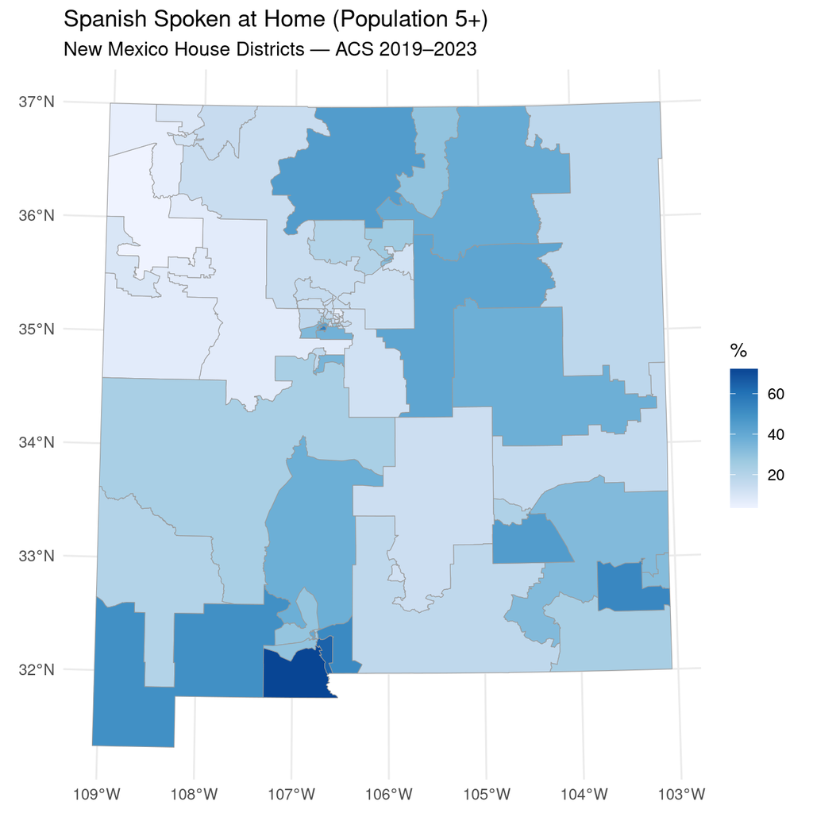

```r
# Choose a good projection for NM — Albers Equal Area (NAD83)
# EPSG: 5070 works well for US-wide data, but NM-specific CRS is EPSG: 6423
nm_house2 <- sf::st_transform(nm_house2, crs = 6423)

# Simple choropleth example — showing Spanish speakers by district
ggplot(
  nm_house2 |>
    subset(variable == "pct_spanish_home_pop5plus") |>
    sf::st_transform(32113)
) +
  geom_sf(aes(fill = estimate), color = "grey60", linewidth = 0.2) +
  scale_fill_distiller(palette = "Blues",
                       direction = 1,
                       na.value = "grey85") +
  theme_minimal(base_size = 12) +
  labs(
    title = "Spanish Spoken at Home (Population 5+)",
    subtitle = "New Mexico House Districts — ACS 2019–2023",
    fill = "%"
  )
```

## Fin

The **Data Profile tables** are particularly useful because they contain many commonly-used demographic and economic indicators already calculated as percentages, saving you from having to compute them manually from detailed tables.